# Data wrangling in Python - Data wrangling with Pandas - 1

One should look for what is and not what he thinks should be. (Albert Einstein)

# Data Wrangling with Pandas: Topic introduction

In this part of the course, we will cover the following concepts:

- Pandas use cases and basic operations
- Dataframe definition and manipulation

# Warm up

- In the next few modules, we will use another popular Python library, Pandas, to continue performing some basic operations
- Python can open a lot of analytical doors, even when you’re just starting out
- Take a few minutes to skim through [this list of 12 cool data science projects](https://towardsdatascience.com/12-cool-data-science-projects-ideas-for-beginners-and-experts-fc75b5498e03)
- Which application most interests you? Why?

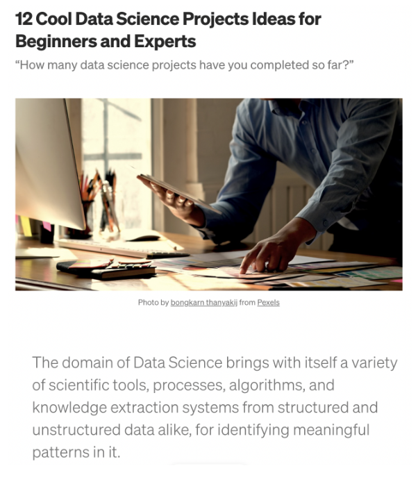

# Module completion checklist

| Objective | Complete |
| --- | --- |
| Summarize use cases of Pandas |  |
| Demonstrate use of basic operations on series |  |

# Dataset manipulation with Pandas

- Pandas is a powerful library for cleaning and analyzing datasets in Python
- A dataset is a collection of data, usually in tabular format, where:
  - Every column represents a particular **variable**
  - Every row represents a given **record**
- We learned about NumPy, to help us work with arrays of numbers, one very specific kind of dataset
- Pandas will help us with cleaning and analyzing datasets of all kinds
- For complete documentation, [click here](https://pandas.pydata.org/)

# A little more about Pandas

- Pandas is an effective tool to read, write and manipulate data
- Pandas contains tools to perform high-performance merging and joining datasets
- Pandas is highly optimized for performance, with critical code paths written in C

[figure not shown]

[figure not shown]

# Import pandas and pathlib

- Let’s import the `pandas` library
- **Note:** it is not required that you also import `numpy` in order to use `pandas`
- However, you will often see both of them imported since many projects make use of both

```python
import numpy as np
import pandas as pd
```

- We will now introduce a package that allows you to reference your working directory
- This will be the directory where your data is stored, allowing you to import data directly from there

```python
from pathlib import Path
```

# Directory settings

- In order to maximize the efficiency of your workflow, you should encode your directory structure into `variables`
- We will use the `pathlib` library
- Let the `main_dir` be the variable corresponding to your `course` folder
- Let `data_dir` be the variable corresponding to your `data` folder

```python
# Set 'main_dir' to location of the project folder
home_dir = Path(".").resolve()
main_dir = home_dir.parent.parent
print(main_dir)
```

[output not shown]

```python
data_dir = str(main_dir) + "/data"
print(data_dir)
```

[output not shown]

# Module completion checklist

| Objective | Complete |
| --- | --- |
| Summarize use cases of Pandas | **✔** |
| Demonstrate use of basic operations on series |  |

# Series

- The first Pandas object we’ll learn about is a `Series`, which has many more additional properties and methods than a NumPy `array`
- [Click here to learn more](https://pandas.pydata.org/pandas-docs/stable/generated/pandas.Series.html)
- We can create a `Series` from a normal Python `list`

```python
num_series = pd.Series([45, 89, 67, 33])
print(num_series)
```

```
0    45
1    89
2    67
3    33
dtype: int64
```

- The in the series are actually stored in an `ndarray`
- To extract just the values as an `ndarray`, use the `.values` property of `Series`

```python
print(num_series.values)
```

```
[45 89 67 33]
```

# Date series: ranges by month

- Pandas supports series of dates, making it a great choice for time series analysis
- Date series can be created in a couple ways

```python
# Create a date range in monthly intervals
print(pd.date_range(start = '20170101', end = '20170331', freq = 'M'))
```

```
DatetimeIndex(['2017-01-31', '2017-02-28', '2017-03-31'], dtype='datetime64[ns]', freq='M')
```

```python
# Create a date range with no end date, but specifying start date, frequency, and number of periods
print(pd.date_range(start = '20170101', freq = 'M', periods = 4))
```

```
DatetimeIndex(['2017-01-31', '2017-02-28', '2017-03-31', '2017-04-30'], dtype='datetime64[ns]', freq='M')
```

# Date series: ranges by hour

- This function can also create hourly series

```python
print(pd.date_range(start = '20170101', end = '20170102', freq = 'H'))
```

```
DatetimeIndex(['2017-01-01 00:00:00', '2017-01-01 01:00:00',
               '2017-01-01 02:00:00', '2017-01-01 03:00:00',
               '2017-01-01 04:00:00', '2017-01-01 05:00:00',
               '2017-01-01 06:00:00', '2017-01-01 07:00:00',
               '2017-01-01 08:00:00', '2017-01-01 09:00:00',
               '2017-01-01 10:00:00', '2017-01-01 11:00:00',
               '2017-01-01 12:00:00', '2017-01-01 13:00:00',
               '2017-01-01 14:00:00', '2017-01-01 15:00:00',
               '2017-01-01 16:00:00', '2017-01-01 17:00:00',
               '2017-01-01 18:00:00', '2017-01-01 19:00:00',
               '2017-01-01 20:00:00', '2017-01-01 21:00:00',
               '2017-01-01 22:00:00', '2017-01-01 23:00:00',
               '2017-01-02 00:00:00'],
              dtype='datetime64[ns]', freq='H')
```

- You can create `Series` by year, by minute, by second, without needing a date
- Many formats are available

# Series methods

- `Series` are more powerful than base Python lists due to the additional attributes and methods they possess

```python
norm_series = pd.Series(np.arange(5, 20, 5))
print(norm_series)
```

```
0     5
1    10
2    15
dtype: int64
```

- Here `0`, `1` and `2` in the first column specify the index
- `5`, `10` and `15` are the values at the corresponding index in the `Series`

# Series methods (cont’d)

- Here is more information about the `pandas.Series`

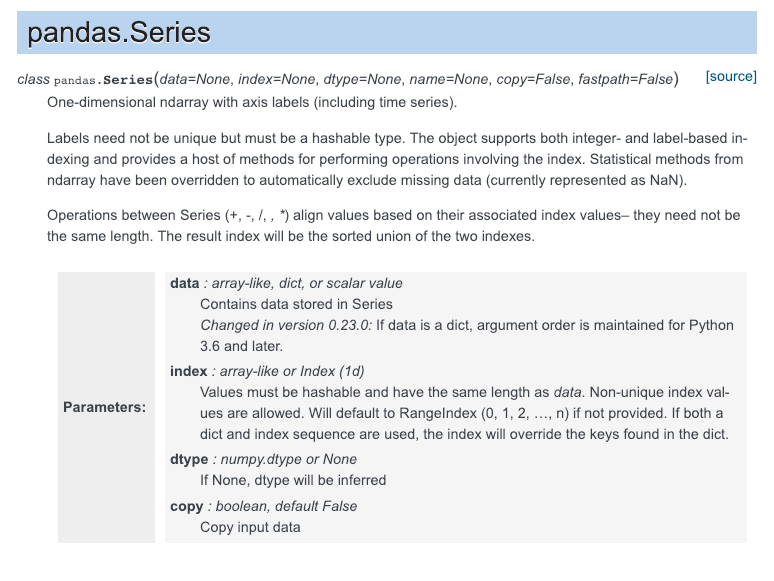

# Series - functions

- Now let’s apply some mathematical functions to this `Series`

```python
print(norm_series.shape)    #<- number of rows and columns
```

```
(3,)
```

```python
print(norm_series.mean())   #<- series mean
```

```
10.0
```

```python
print(norm_series.median()) #<- series median
```

```
10.0
```

```python
print(norm_series.std())    #<- series std deviation
```

```
5.0
```

# Series - functions

- Here are some ways to count items in a `Series`

```python
# Show only unique values.
print(norm_series.unique())
```

```
[ 5 10 15]
```

```python
# Show number of unique values.
print(norm_series.nunique())
```

```
3
```

```python
# Show counts of unique values.
print(norm_series.value_counts())
```

```
5     1
10    1
15    1
dtype: int64
```

```python
# Position of the min value.
print(norm_series.idxmin())
```

```
0
```

```python
# Position of the max value.
print(norm_series.idxmax())
```

```
2
```

# Series - rank

- We can rank items in ascending order:

```python
# Ranks from smallest to largest.
print(norm_series.rank())
```

```
0    1.0
1    2.0
2    3.0
dtype: float64
```

- And in descending order:

```python
# Ranks from largest to smallest.
print(norm_series.rank(ascending = False))
```

```
0    3.0
1    2.0
2    1.0
dtype: float64
```

# Series - sort and cumulative sum

- We can sort `Series`:

```python
# Sorts values.
print(norm_series.sort_values())
```

```
0     5
1    10
2    15
dtype: int64
```

- And find the cumulative sum:

```python
# Returns a series that is the cumulative sum of `norm_series`.
print(norm_series.cumsum())
```

```
0     5
1    15
2    30
dtype: int64
```

# Knowledge check

[figure not shown]

Link: https://forms.gle/JQaTy2Dthr1L27Yd9

# Module completion checklist

| Objective | Complete |
| --- | --- |
| Summarize use cases of Pandas | **✔** |
| Demonstrate use of basic operations on series | **✔** |

# Congratulations on completing this module!

You are now ready to try Tasks 1-4 in the Exercise for this topic

[figure not shown]